# PRECIS-2 Scores in PragMeta: Human Consensus vs Human Rater 1

### Score comparisons of 56 publications

| Ref. | Author & Year | weighted κ | agreement | pooled weighted κ | pooled agreement |
| --- | --- | --- | --- | --- | --- |
| 648 | CORONIS Collaborative Group (2013) | 0.685714285714286 | 0.444444444444444 | 0.721649484536082 | 0.666666666666667 |
| 650 | van Dijk-de Vries. A, (2015) | 0.558282208588957 | 0.444444444444444 | 0.26530612244898 | 0.555555555555556 |
| 651 | Price. D, (2011) | 0.4375 | 0.555555555555556 | 0.289473684210526 | 0.666666666666667 |
| 655 | Galdiz, J. B. (2020) | 0.599009900990099 | 0.666666666666667 | 0.597014925373134 | 0.666666666666667 |
| 657 | Arntzen E. (2019) | 0.833333333333333 | 0.777777777777778 | 0.780487804878049 | 0.888888888888889 |
| 662 | Bogosian A. (2015) | 0.696629213483146 | 0.666666666666667 | 0.714285714285714 | 0.777777777777778 |
| 663 | Callesen J. (2020) | 1 | 1 | 1 | 1 |
| 664 | Carter A. (2014) | 0.338235294117647 | 0.555555555555556 | 0.142857142857143 | 0.555555555555556 |
| 665 | Cooper C. (2011) | 0.10989010989011 | 0.333333333333333 | 0 | 0.888888888888889 |
| 666 | Cutter G. (2019) | 0.768041237113402 | 0.777777777777778 | 0.8125 | 0.888888888888889 |

[output cut: 46 more lines]

### Score heatmaps (unpooled / pooled)

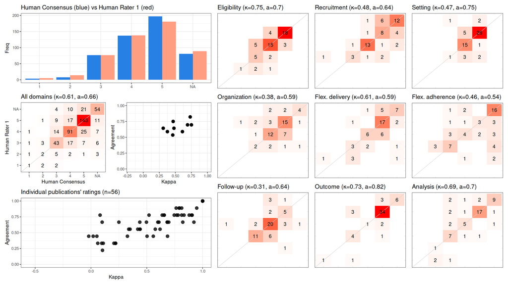

### Individual results

#### 648. CORONIS Collaborative Group (2013): *Caesarean section surgical techniques (CORONIS): a fractional, factorial, unmasked, randomised controlled trial*

PRECIS-2

|  | D1 | D2 | D3 | D4 | D5 | D6 | D7 | D8 | D9 |
| --- | --- | --- | --- | --- | --- | --- | --- | --- | --- |
| Human Consensus | 4 | NA | 5 | 5 | 3 | NA | 5 | 3 | 3 |
| Human Rater 1 | 4 | NA | 5 | 4 | 2 | NA | 4 | 1 | 1 |

#### 650. [van Dijk-de Vries. A, (2015): *Lessons learnt from a cluster-randomised trial evaluating the effectiveness of Self-Management Support (SMS) delivered by practice nurses in routine diabetes care*](https://doi.org/10.1136/bmjopen-2014-007014)

PRECIS-2

|  | D1 | D2 | D3 | D4 | D5 | D6 | D7 | D8 | D9 |
| --- | --- | --- | --- | --- | --- | --- | --- | --- | --- |
| Human Consensus | 3 | 4 | 5 | 4 | 5 | NA | 4 | 5 | 3 |
| Human Rater 1 | 4 | 4 | 5 | 3 | NA | NA | 3 | 4 | 3 |

#### 651. [Price. D, (2011): *Leukotriene antagonists as first-line or add-on asthma-controller therapy*](https://doi.org/10.1056/NEJMoa1010846)

PRECIS-2

|  | D1 | D2 | D3 | D4 | D5 | D6 | D7 | D8 | D9 |
| --- | --- | --- | --- | --- | --- | --- | --- | --- | --- |
| Human Consensus | 5 | 5 | 5 | NA | 4 | 4 | 4 | 5 | 4 |
| Human Rater 1 | 5 | NA | 5 | NA | 3 | NA | 4 | 5 | 5 |

#### 655. [Galdiz, J. B. (2020): *Telerehabilitation Programme as a Maintenance Strategy for COPD Patients: A 12-Month Randomized Clinical Trial*](https://doi.org/10.1016/j.arbres.2020.03.034)

PRECIS-2

|  | D1 | D2 | D3 | D4 | D5 | D6 | D7 | D8 | D9 |
| --- | --- | --- | --- | --- | --- | --- | --- | --- | --- |
| Human Consensus | 3 | NA | 5 | 4 | 5 | 3 | 4 | 3 | 3 |
| Human Rater 1 | 2 | NA | 5 | NA | 5 | 5 | 4 | 3 | 3 |

#### 657. [Arntzen E. (2019): *Group-Based Individualized Comprehensive Core Stability Intervention Improves Balance in Persons With Multiple Sclerosis: A Randomized Controlled Trial.*](https://doi.org/10.1093/ptj/pzz017)

PRECIS-2

|  | D1 | D2 | D3 | D4 | D5 | D6 | D7 | D8 | D9 |
| --- | --- | --- | --- | --- | --- | --- | --- | --- | --- |
| Human Consensus | 3 | 4 | 5 | 4 | 5 | 4 | 4 | 5 | 5 |
| Human Rater 1 | 2 | 4 | 5 | 4 | 5 | 5 | 4 | 5 | 5 |

#### 662. [Bogosian A. (2015): *Distress improves after mindfulness training for progressive MS: A pilot randomised trial*](https://doi.org/10.1177/1352458515576261)

PRECIS-2

|  | D1 | D2 | D3 | D4 | D5 | D6 | D7 | D8 | D9 |
| --- | --- | --- | --- | --- | --- | --- | --- | --- | --- |
| Human Consensus | 5 | 4 | 5 | 4 | 3 | NA | 3 | 5 | 5 |
| Human Rater 1 | 4 | 4 | 5 | 3 | 3 | 2 | 3 | 5 | 5 |

#### 663. [Callesen J. (2020): *How do resistance training and balance and motor control training affect gait performance and fatigue impact in people with multiple sclerosis? A randomized controlled multi-center study*](https://doi.org/10.1177/1352458519865740)

PRECIS-2

|  | D1 | D2 | D3 | D4 | D5 | D6 | D7 | D8 | D9 |
| --- | --- | --- | --- | --- | --- | --- | --- | --- | --- |
| Human Consensus | 4 | 4 | 5 | 5 | 5 | 5 | 4 | 5 | 3 |
| Human Rater 1 | 4 | 4 | 5 | 5 | 5 | 5 | 4 | 5 | 3 |

#### 664. [Carter A. (2014): *Pragmatic intervention for increasing self-directed exercise behaviour and improving important health outcomes in people with multiple sclerosis: a randomised controlled trial*](https://doi.org/10.1177/1352458513519354)

PRECIS-2

|  | D1 | D2 | D3 | D4 | D5 | D6 | D7 | D8 | D9 |
| --- | --- | --- | --- | --- | --- | --- | --- | --- | --- |
| Human Consensus | 3 | 4 | 4 | 5 | 5 | 3 | 4 | 5 | 4 |
| Human Rater 1 | 3 | 3 | 4 | NA | NA | 4 | 4 | 5 | 4 |

#### 665. [Cooper C. (2011): *Computerised cognitive behavioural therapy for the treatment of depression in people with multiple sclerosis: external pilot trial*](https://doi.org/10.1186/1745-6215-12-259)

PRECIS-2

|  | D1 | D2 | D3 | D4 | D5 | D6 | D7 | D8 | D9 |
| --- | --- | --- | --- | --- | --- | --- | --- | --- | --- |
| Human Consensus | 4 | 4 | 5 | 5 | 5 | 4 | 4 | 5 | 4 |
| Human Rater 1 | 4 | 5 | 4 | 4 | 4 | 2 | 5 | 5 | 4 |

#### 666. [Cutter G. (2019): *Higher satisfaction and adherence with glatiramer acetate 40 mg/mL TIW vs 20 mg/mL QD in RRMS*](https://doi.org/10.1016/j.msard.2019.04.036)

PRECIS-2

|  | D1 | D2 | D3 | D4 | D5 | D6 | D7 | D8 | D9 |
| --- | --- | --- | --- | --- | --- | --- | --- | --- | --- |
| Human Consensus | 4 | NA | 5 | NA | NA | 4 | 3 | 5 | 5 |
| Human Rater 1 | 5 | NA | 5 | NA | NA | NA | 3 | 5 | 5 |

#### 668. [Dodd K. J. (2011): *Progressive resistance training did not improve walking but can improve muscle performance, quality of life and fatigue in adults with multiple sclerosis: a randomized controlled trial*](https://doi.org/10.1177/1352458511409084)

PRECIS-2

|  | D1 | D2 | D3 | D4 | D5 | D6 | D7 | D8 | D9 |
| --- | --- | --- | --- | --- | --- | --- | --- | --- | --- |
| Human Consensus | 4 | 3 | 5 | 5 | NA | 4 | 4 | 5 | 4 |
| Human Rater 1 | 4 | 4 | 5 | NA | 5 | 4 | 4 | 5 | 4 |

#### 669. [Feys P. (2019): *Effects of an individual 12-week community-located “start-to-run” program on physical capacity, walking, fatigue, cognitive function, brain volumes, and structures in persons with multiple sclerosis*](https://doi.org/10.1177/1352458517740211)

PRECIS-2

|  | D1 | D2 | D3 | D4 | D5 | D6 | D7 | D8 | D9 |
| --- | --- | --- | --- | --- | --- | --- | --- | --- | --- |
| Human Consensus | 3 | 4 | 5 | 2 | 5 | 2 | 1 | 3 | 3 |
| Human Rater 1 | 4 | 4 | 5 | 5 | 4 | 3 | 4 | 5 | 5 |

PRECIS-2

[output not shown]

#### 671. Freeman J. (2019): *Assessment of a home-based standing frame programme in people with progressive multiple sclerosis (SUMS): a pragmatic, multi-centre, randomised, controlled trial and cost-effectiveness analysis*

PRECIS-2

|  | D1 | D2 | D3 | D4 | D5 | D6 | D7 | D8 | D9 |
| --- | --- | --- | --- | --- | --- | --- | --- | --- | --- |
| Human Consensus | 5 | 5 | 5 | 4 | 3 | 2 | 3 | 5 | 3 |
| Human Rater 1 | 5 | 5 | 5 | 5 | 3 | 3 | 3 | 5 | 3 |

#### 673. [Garrett M. (2013): *Exercise in the community for people with minimal gait impairment due to MS: an assessor-blind randomized controlled trial*](https://doi.org/10.1177/1352458512461966)

PRECIS-2

|  | D1 | D2 | D3 | D4 | D5 | D6 | D7 | D8 | D9 |
| --- | --- | --- | --- | --- | --- | --- | --- | --- | --- |
| Human Consensus | 5 | 5 | 5 | NA | 3 | 3 | 5 | 5 | 2 |
| Human Rater 1 | 5 | NA | 5 | 5 | 5 | 3 | 5 | 5 | 1 |

#### 674. [Giovannoni G. (2016): *Alemtuzumab improves preexisting disability in active relapsing-remitting MS patients*](https://doi.org/10.1212/WNL.0000000000003319)

PRECIS-2

|  | D1 | D2 | D3 | D4 | D5 | D6 | D7 | D8 | D9 |
| --- | --- | --- | --- | --- | --- | --- | --- | --- | --- |
| Human Consensus | 3 | NA | 5 | NA | NA | NA | 4 | 5 | NA |
| Human Rater 1 | 3 | 4 | 3 | 3 | 3 | 2 | NA | 5 | NA |

#### 675. [Grossman P. (2010): *MS quality of life, depression, and fatigue improve after mindfulness training: a randomized trial*](https://doi.org/10.1212/WNL.0b013e3181f4d80d)

PRECIS-2

|  | D1 | D2 | D3 | D4 | D5 | D6 | D7 | D8 | D9 |
| --- | --- | --- | --- | --- | --- | --- | --- | --- | --- |
| Human Consensus | 5 | 4 | 3 | 5 | NA | 5 | 5 | 5 | 5 |
| Human Rater 1 | 4 | 4 | NA | 5 | NA | 5 | 5 | 5 | 5 |

#### 677. [Hermens H. (2008): *Clinical assessment of the HELLODOC tele-rehabilitation service*](https://doi.org/)

PRECIS-2

|  | D1 | D2 | D3 | D4 | D5 | D6 | D7 | D8 | D9 |
| --- | --- | --- | --- | --- | --- | --- | --- | --- | --- |
| Human Consensus | 4 | NA | 4 | 5 | NA | NA | 4 | 5 | NA |
| Human Rater 1 | 2 | 5 | 4 | 5 | NA | NA | 4 | 5 | NA |

#### 678. [Higginson I. J. (2009): *Is short-term palliative care cost-effective in multiple sclerosis? A randomized phase II trial*](https://doi.org/10.1016/j.jpainsymman.2009.07.002)

PRECIS-2

|  | D1 | D2 | D3 | D4 | D5 | D6 | D7 | D8 | D9 |
| --- | --- | --- | --- | --- | --- | --- | --- | --- | --- |
| Human Consensus | 4 | 5 | 4 | 4 | 5 | NA | 4 | 5 | 4 |
| Human Rater 1 | 3 | NA | 4 | 5 | 5 | 5 | 4 | NA | 4 |

#### 679. [Jongen P. J. (2019): *Effect of an intensive 3-day social cognitive treatment (can do treatment) on control self-efficacy in patients with relapsing remitting multiple sclerosis and low disability: A single-centre randomized controlled trial*](https://doi.org/10.1371/journal.pone.0223482)

PRECIS-2

|  | D1 | D2 | D3 | D4 | D5 | D6 | D7 | D8 | D9 |
| --- | --- | --- | --- | --- | --- | --- | --- | --- | --- |
| Human Consensus | 4 | 5 | 5 | 4 | 5 | NA | 4 | 5 | 3 |
| Human Rater 1 | 4 | 4 | 5 | 4 | 4 | 4 | 3 | 5 | 5 |

#### 680. [Kiropoulos L. A. (2016): *A pilot randomized controlled trial of a tailored cognitive behavioural therapy based intervention for depressive symptoms in those newly diagnosed with multiple sclerosis*](https://doi.org/10.1186/s12888-016-1152-7)

PRECIS-2

|  | D1 | D2 | D3 | D4 | D5 | D6 | D7 | D8 | D9 |
| --- | --- | --- | --- | --- | --- | --- | --- | --- | --- |
| Human Consensus | 4 | 3 | 4 | 4 | 5 | 5 | 3 | 5 | 5 |
| Human Rater 1 | 4 | 3 | 4 | 4 | 5 | 4 | 4 | 5 | 5 |

#### 681. [Learmonth Y. C. (2012): *The effects of a 12-week leisure centre-based, group exercise intervention for people moderately affected with multiple sclerosis: a randomized controlled pilot study*](https://doi.org/10.1177/0269215511423946)

PRECIS-2

|  | D1 | D2 | D3 | D4 | D5 | D6 | D7 | D8 | D9 |
| --- | --- | --- | --- | --- | --- | --- | --- | --- | --- |
| Human Consensus | 4 | 5 | 5 | 5 | 3 | 3 | 4 | 5 | 3 |
| Human Rater 1 | 4 | 3 | 5 | 4 | 2 | NA | 4 | NA | NA |

#### 682. [Mayo N. E. (2020): *Participation in and outcomes from a 12-month tailored exercise programme for people with multiple sclerosis (MSTEP�): a randomized trial*](https://doi.org/10.1177/0269215520923089)

PRECIS-2

|  | D1 | D2 | D3 | D4 | D5 | D6 | D7 | D8 | D9 |
| --- | --- | --- | --- | --- | --- | --- | --- | --- | --- |
| Human Consensus | 4 | 4 | 5 | 5 | 5 | 2 | 3 | 1 | 2 |
| Human Rater 1 | 4 | 4 | 5 | 5 | 5 | 3 | 4 | 1 | 1 |

#### 684. [Miller L. (2011): *Evaluation of a home-based physiotherapy programme for those with moderate to severe multiple sclerosis: a randomized controlled pilot study*](https://doi.org/10.1177/0269215511398376)

PRECIS-2

|  | D1 | D2 | D3 | D4 | D5 | D6 | D7 | D8 | D9 |
| --- | --- | --- | --- | --- | --- | --- | --- | --- | --- |
| Human Consensus | 4 | 4 | 4 | 5 | 5 | NA | 4 | 5 | NA |
| Human Rater 1 | 4 | 4 | 5 | 4 | 4 | 5 | 3 | 5 | 4 |

#### 685. [O’Hara L. (2002): *Evaluation of the effectiveness of professionally guided self-care for people with multiple sclerosis living in the community: a randomized controlled trial*](https://doi.org/10.1191/0269215502cr478oa)

PRECIS-2

|  | D1 | D2 | D3 | D4 | D5 | D6 | D7 | D8 | D9 |
| --- | --- | --- | --- | --- | --- | --- | --- | --- | --- |
| Human Consensus | 5 | NA | 4 | 3 | 5 | NA | 5 | 5 | 5 |
| Human Rater 1 | 5 | 5 | 4 | 3 | 4 | NA | NA | 5 | NA |

#### 686. [Papeix C. (2015): *Evaluation of an integrated multidisciplinary approach in multiple sclerosis care: A prospective, randomized, controlled study*](https://doi.org/10.1177/2055217315608864)

PRECIS-2

|  | D1 | D2 | D3 | D4 | D5 | D6 | D7 | D8 | D9 |
| --- | --- | --- | --- | --- | --- | --- | --- | --- | --- |
| Human Consensus | 4 | 5 | 4 | 5 | 5 | NA | 4 | 5 | 5 |
| Human Rater 1 | 3 | 3 | 3 | 5 | 5 | 3 | 4 | 4 | 5 |

#### 687. [Paul L. (2014): *Web-based physiotherapy for people moderately affected with Multiple Sclerosis; quantitative and qualitative data from a randomized, controlled pilot study*](https://doi.org/10.1177/0269215514527995)

PRECIS-2

|  | D1 | D2 | D3 | D4 | D5 | D6 | D7 | D8 | D9 |
| --- | --- | --- | --- | --- | --- | --- | --- | --- | --- |
| Human Consensus | 2 | 5 | 4 | 5 | 4 | 4 | 3 | 5 | 3 |
| Human Rater 1 | 2 | 5 | 5 | 5 | 4 | 4 | 3 | 5 | 3 |

#### 688. [Pozzilli C. (2002): *Home based management in multiple sclerosis: results of a randomised controlled trial*](https://doi.org/10.1136/jnnp.73.3.250)

PRECIS-2

|  | D1 | D2 | D3 | D4 | D5 | D6 | D7 | D8 | D9 |
| --- | --- | --- | --- | --- | --- | --- | --- | --- | --- |
| Human Consensus | 5 | NA | 5 | 3 | 5 | NA | 4 | 5 | 5 |
| Human Rater 1 | 5 | 5 | 5 | 3 | 5 | 3 | 4 | 5 | 5 |

#### 689. [Renfrew L. M. (2019): *The clinical- and cost-effectiveness of functional electrical stimulation and ankle-foot orthoses for foot drop in Multiple Sclerosis: a multicentre randomized trial*](https://doi.org/10.1177/0269215519842254)

PRECIS-2

|  | D1 | D2 | D3 | D4 | D5 | D6 | D7 | D8 | D9 |
| --- | --- | --- | --- | --- | --- | --- | --- | --- | --- |
| Human Consensus | 3 | 5 | 5 | 5 | 4 | NA | 4 | 5 | NA |
| Human Rater 1 | 4 | 5 | 3 | 5 | 3 | 3 | 3 | 5 | 5 |

#### 690. [Solari A. (2018): *Randomized controlled trial of a home-based palliative approach for people with severe multiple sclerosis*](https://doi.org/10.1177/1352458517704078)

PRECIS-2

|  | D1 | D2 | D3 | D4 | D5 | D6 | D7 | D8 | D9 |
| --- | --- | --- | --- | --- | --- | --- | --- | --- | --- |
| Human Consensus | 4 | NA | 5 | 5 | 5 | NA | 3 | 5 | 5 |
| Human Rater 1 | 5 | NA | NA | 3 | NA | NA | 3 | 5 | 5 |

#### 691. [Thomas S. (2013): *A pragmatic parallel arm multi-centre randomised controlled trial to assess the effectiveness and cost-effectiveness of a group-based fatigue management programme (FACETS) for people with multiple sclerosis*](https://doi.org/10.1136/jnnp-2012-303816)

PRECIS-2

|  | D1 | D2 | D3 | D4 | D5 | D6 | D7 | D8 | D9 |
| --- | --- | --- | --- | --- | --- | --- | --- | --- | --- |
| Human Consensus | 4 | 4 | 4 | 4 | 3 | 5 | 4 | 5 | 5 |
| Human Rater 1 | 4 | 4 | 4 | 4 | 3 | 5 | 4 | 5 | 5 |

#### 692. [Torkhani E. (2021): *Improving Health of People With Multiple Sclerosis From a Multicenter Randomized Controlled Study in Parallel Groups: Preliminary Results on the Efficacy of a Mindfulness Intervention and Intention Implementation Associated With a Physical Activity Program*](https://doi.org/10.3389/fpsyg.2021.767784)

PRECIS-2

|  | D1 | D2 | D3 | D4 | D5 | D6 | D7 | D8 | D9 |
| --- | --- | --- | --- | --- | --- | --- | --- | --- | --- |
| Human Consensus | 5 | 5 | 5 | 5 | 5 | 4 | 5 | 5 | 5 |
| Human Rater 1 | 5 | 5 | 5 | 4 | 5 | 4 | 2 | 5 | 5 |

#### 693. [Velikonja O. (2010): *Influence of sports climbing and yoga on spasticity, cognitive function, mood and fatigue in patients with multiple sclerosis*](https://doi.org/10.1016/j.clineuro.2010.03.006)

PRECIS-2

|  | D1 | D2 | D3 | D4 | D5 | D6 | D7 | D8 | D9 |
| --- | --- | --- | --- | --- | --- | --- | --- | --- | --- |
| Human Consensus | 5 | NA | 4 | 4 | NA | 3 | 4 | 5 | NA |
| Human Rater 1 | 4 | NA | 4 | 4 | NA | 4 | 4 | 3 | NA |

#### 694. [Vermöhlen V. (2018): *Hippotherapy for patients with multiple sclerosis: A multicenter randomized controlled trial (MS-HIPPO)*](https://doi.org/10.1177/1352458517721354)

PRECIS-2

|  | D1 | D2 | D3 | D4 | D5 | D6 | D7 | D8 | D9 |
| --- | --- | --- | --- | --- | --- | --- | --- | --- | --- |
| Human Consensus | 3 | NA | 5 | 3 | 4 | NA | 4 | 5 | 5 |
| Human Rater 1 | 4 | 4 | 5 | 5 | 4 | 3 | 4 | 5 | 3 |

#### 695. [Ward C. D. (2004): *Education for people with progressive neurological conditions can have negative effects: evidence from a randomized controlled trial*](https://doi.org/10.1191/0269215504cr792oa)

PRECIS-2

|  | D1 | D2 | D3 | D4 | D5 | D6 | D7 | D8 | D9 |
| --- | --- | --- | --- | --- | --- | --- | --- | --- | --- |
| Human Consensus | 5 | 4 | 4 | 4 | 5 | NA | 4 | 5 | 5 |
| Human Rater 1 | 5 | 4 | 5 | 5 | 5 | NA | 4 | 5 | 5 |

#### 696. [Weinstock-Guttman B. (2016): *Randomised natalizumab discontinuation study: taper protocol may prevent disease reactivation*](https://doi.org/10.1136/jnnp-2015-312221)

PRECIS-2

|  | D1 | D2 | D3 | D4 | D5 | D6 | D7 | D8 | D9 |
| --- | --- | --- | --- | --- | --- | --- | --- | --- | --- |
| Human Consensus | 5 | NA | 4 | 3 | 5 | NA | 3 | 4 | NA |
| Human Rater 1 | 5 | NA | 3 | 4 | 5 | NA | 3 | 4 | NA |

#### 697. [Williams K. L. (2021): *Center-Based Group and Home-Based Individual Exercise Programs Have Similar Impacts on Gait and Balance in People With Multiple Sclerosis: A Randomized Trial*](https://doi.org/10.1002/pmrj.12377)

PRECIS-2

|  | D1 | D2 | D3 | D4 | D5 | D6 | D7 | D8 | D9 |
| --- | --- | --- | --- | --- | --- | --- | --- | --- | --- |
| Human Consensus | 4 | NA | 4 | 4 | 4 | 4 | 4 | 5 | 4 |
| Human Rater 1 | 4 | 5 | 5 | 4 | 4 | 4 | 4 | 5 | NA |

#### 705. [Petrella, R. J. (2017): *Hockey Fans in Training: A Pilot Pragmatic Randomized Controlled Trial*](https://doi.org/10.1249/MSS.0000000000001380)

PRECIS-2

|  | D1 | D2 | D3 | D4 | D5 | D6 | D7 | D8 | D9 |
| --- | --- | --- | --- | --- | --- | --- | --- | --- | --- |
| Human Consensus | 5 | 1 | 5 | 5 | 5 | 3 | 4 | 5 | 4 |
| Human Rater 1 | 5 | 3 | NA | 4 | 5 | 4 | 3 | 5 | 4 |

#### 712. [Mafetoni, R. R. (2016): *The effects of acupressure on labor pains during child birth: randomized clinical trial1*](https://doi.org/10.1590/1518-8345.0739.2738)

PRECIS-2

|  | D1 | D2 | D3 | D4 | D5 | D6 | D7 | D8 | D9 |
| --- | --- | --- | --- | --- | --- | --- | --- | --- | --- |
| Human Consensus | 5 | 5 | 4 | 4 | 1 | NA | 4 | 5 | 3 |
| Human Rater 1 | 5 | 5 | 4 | 4 | 2 | NA | NA | 5 | NA |

#### 713. [Jonsdottir, H. (2015): *Effectiveness of a partnership-based self-management programme for patients with mild and moderate chronic obstructive pulmonary disease: a pragmatic randomized controlled trial*](https://doi.org/10.1111/jan.12728)

PRECIS-2

|  | D1 | D2 | D3 | D4 | D5 | D6 | D7 | D8 | D9 |
| --- | --- | --- | --- | --- | --- | --- | --- | --- | --- |
| Human Consensus | 4 | 4 | 3 | NA | NA | NA | 4 | 3 | 2 |
| Human Rater 1 | 5 | 4 | 3 | NA | 5 | NA | 5 | 5 | 2 |

#### 714. [Pinnock, H. (2003): *Accessibility, acceptability, and effectiveness in primary care of routine telephone review of asthma: pragmatic, randomised controlled trial*](https://doi.org/10.1136/bmj.326.7387.477)

PRECIS-2

|  | D1 | D2 | D3 | D4 | D5 | D6 | D7 | D8 | D9 |
| --- | --- | --- | --- | --- | --- | --- | --- | --- | --- |
| Human Consensus | 3 | 4 | 4 | 5 | 5 | NA | 5 | 5 | 3 |
| Human Rater 1 | 3 | 4 | 3 | 4 | 5 | 4 | 5 | 5 | 3 |

#### 715. [Ndosi, M. (2014): *The outcome and cost-effectiveness of nurse-led care in people with rheumatoid arthritis: a multicentre randomised controlled trial*](https://doi.org/10.1136/annrheumdis-2013-203403)

PRECIS-2

|  | D1 | D2 | D3 | D4 | D5 | D6 | D7 | D8 | D9 |
| --- | --- | --- | --- | --- | --- | --- | --- | --- | --- |
| Human Consensus | 5 | NA | 5 | 4 | 5 | NA | 5 | 3 | 3 |
| Human Rater 1 | 5 | NA | 5 | 4 | 5 | 5 | 4 | 5 | 4 |

#### 722. [Patel. A. (2015): *A pragmatic randomized trial of a polypill-based strategy to improve use of indicated preventive treatments in people at high cardiovascular disease risk*](https://doi.org/10.1177/2047487314530382)

PRECIS-2

|  | D1 | D2 | D3 | D4 | D5 | D6 | D7 | D8 | D9 |
| --- | --- | --- | --- | --- | --- | --- | --- | --- | --- |
| Human Consensus | 4 | NA | 5 | 5 | 5 | 5 | 4 | 3 | 4 |
| Human Rater 1 | 4 | NA | 5 | 5 | 5 | 4 | 3 | 3 | 3 |

#### 725. [Rangan, A. (2015): *Surgical vs nonsurgical treatment of adults with displaced fractures of the proximal humerus: the PROFHER randomized clinical trial*](https://doi.org/10.1001/jama.2015.1629)

PRECIS-2

|  | D1 | D2 | D3 | D4 | D5 | D6 | D7 | D8 | D9 |
| --- | --- | --- | --- | --- | --- | --- | --- | --- | --- |
| Human Consensus | 4 | NA | 5 | 5 | 4 | NA | 5 | 5 | 3 |
| Human Rater 1 | 4 | NA | 5 | 5 | 4 | NA | 4 | 5 | 4 |

#### 733. [Iliffe, S. (2015): *Promoting physical activity in older people in general practice: ProAct65+ cluster randomised controlled trial*](https://doi.org/10.3399/bjgp15X687361)

PRECIS-2

|  | D1 | D2 | D3 | D4 | D5 | D6 | D7 | D8 | D9 |
| --- | --- | --- | --- | --- | --- | --- | --- | --- | --- |
| Human Consensus | 4 | 4 | 5 | 4 | 5 | 3 | 3 | 3 | 3 |
| Human Rater 1 | 5 | 4 | 5 | 4 | NA | 3 | 3 | 3 | 3 |

#### 1528. [Humphreys I. (2013): *Cost-effectiveness of an adjustment group for people with multiple sclerosis and low mood: a randomized trial*](https://doi.org/10.1177/0269215513488608)

PRECIS-2

|  | D1 | D2 | D3 | D4 | D5 | D6 | D7 | D8 | D9 |
| --- | --- | --- | --- | --- | --- | --- | --- | --- | --- |
| Human Consensus | 3 | 3 | 4 | 4 | 4 | NA | 4 | 5 | 5 |
| Human Rater 1 | 3 | 3 | 4 | 4 | NA | NA | 4 | 5 | 5 |

#### 1529. [Khayeri F. (2016): *Effect of Fordyce Happiness Model on depression, stress, anxiety, and fatigue in patients with multiple sclerosis*](https://doi.org/10.1016/j.ctcp.2016.09.009)

PRECIS-2

|  | D1 | D2 | D3 | D4 | D5 | D6 | D7 | D8 | D9 |
| --- | --- | --- | --- | --- | --- | --- | --- | --- | --- |
| Human Consensus | 5 | 5 | 4 | NA | 4 | NA | 5 | NA | NA |
| Human Rater 1 | 5 | NA | 4 | NA | 4 | NA | 5 | NA | NA |

#### 1567. [Stuifbergen A.K. (2018): *Computer-assisted cognitive rehabilitation in persons with multiple sclerosis: Results of a multi-site randomized controlled trial with six month follow-up*](https://doi.org/10.1016/j.dhjo.2018.02.001)

PRECIS-2

|  | D1 | D2 | D3 | D4 | D5 | D6 | D7 | D8 | D9 |
| --- | --- | --- | --- | --- | --- | --- | --- | --- | --- |
| Human Consensus | 5 | 3 | 5 | 3 | NA | 3 | 3 | 5 | 5 |
| Human Rater 1 | 5 | 3 | 5 | 5 | NA | 3 | 3 | 5 | 5 |

#### 1568. [Riemenschneider M. (2022): *Investigating the potential disease-modifying and neuroprotective efficacy of exercise therapy early in the disease course of multiple sclerosis: The Early Multiple Sclerosis Exercise Study (EMSES)*](https://doi.org/10.1177/13524585221079200)

PRECIS-2

|  | D1 | D2 | D3 | D4 | D5 | D6 | D7 | D8 | D9 |
| --- | --- | --- | --- | --- | --- | --- | --- | --- | --- |
| Human Consensus | 4 | 4 | 4 | 4 | 5 | 3 | 3 | 3 | 5 |
| Human Rater 1 | 4 | NA | 5 | NA | 5 | 3 | 3 | 3 | 5 |

#### 1569. [Straudi S. (2022): *Combining a supervised and home-based task-oriented circuit training improves walking endurance in patients with multiple sclerosis. The MS_TOCT randomized-controlled trial*](https://doi.org/10.1016/j.msard.2022.103721)

PRECIS-2

|  | D1 | D2 | D3 | D4 | D5 | D6 | D7 | D8 | D9 |
| --- | --- | --- | --- | --- | --- | --- | --- | --- | --- |
| Human Consensus | 5 | 5 | 4 | 4 | 5 | 3 | 4 | 5 | 5 |
| Human Rater 1 | 5 | 5 | 4 | 4 | 5 | 3 | 4 | 5 | 5 |

#### 1570. [Mazdeh M. (2010): *The therapeutic effect of Avonex, Rebif and Betaferon on EDSS and relapse in multiple sclerosis: a comparative study*](https://doi.org/)

PRECIS-2

|  | D1 | D2 | D3 | D4 | D5 | D6 | D7 | D8 | D9 |
| --- | --- | --- | --- | --- | --- | --- | --- | --- | --- |
| Human Consensus | 3 | 5 | 4 | 5 | NA | NA | 5 | NA | NA |
| Human Rater 1 | 3 | 5 | 4 | 5 | NA | NA | 5 | NA | NA |

#### 1769. Millar J.H. (1967): *Long-term treatment of multiple sclerosis with corticotrophin*

PRECIS-2

|  | D1 | D2 | D3 | D4 | D5 | D6 | D7 | D8 | D9 |
| --- | --- | --- | --- | --- | --- | --- | --- | --- | --- |
| Human Consensus | 5 | NA | 5 | 5 | 5 | NA | 4 | NA | NA |
| Human Rater 1 | 5 | NA | 5 | 5 | NA | NA | 4 | NA | NA |

#### 1770. [Hoogstraten M.C. (1990): *Long-term effect of ACTH treatment of relapse in multiple sclerosis*](https://doi.org/10.1111/j.1600-0404.1990.tb01590.x)

PRECIS-2

|  | D1 | D2 | D3 | D4 | D5 | D6 | D7 | D8 | D9 |
| --- | --- | --- | --- | --- | --- | --- | --- | --- | --- |
| Human Consensus | 5 | NA | 5 | 5 | NA | NA | 4 | NA | NA |
| Human Rater 1 | 5 | NA | 5 | 5 | NA | NA | 4 | NA | NA |

#### 1771. [Langeskov-Christensen M. (2021): *Efficacy of high-intensity aerobic exercise on cognitive performance in people with multiple sclerosis: A randomized controlled trial*](https://doi.org/10.1177/1352458520973619)

PRECIS-2

|  | D1 | D2 | D3 | D4 | D5 | D6 | D7 | D8 | D9 |
| --- | --- | --- | --- | --- | --- | --- | --- | --- | --- |
| Human Consensus | 5 | NA | 4 | 5 | 4 | 3 | 3 | NA | 5 |
| Human Rater 1 | 5 | NA | 4 | 5 | 4 | 3 | 3 | NA | 5 |

#### 1772. [Calkwood J. (2014): *Impact of a switch to fingolimod versus staying on glatiramer acetate or beta interferons on patient- and physician-reported outcomes in relapsing multiple sclerosis: post hoc analyses of the EPOC trial*](https://doi.org/10.1186/s12883-014-0220-1)

PRECIS-2

|  | D1 | D2 | D3 | D4 | D5 | D6 | D7 | D8 | D9 |
| --- | --- | --- | --- | --- | --- | --- | --- | --- | --- |
| Human Consensus | 3 | 5 | 5 | 5 | NA | NA | 4 | 5 | 5 |
| Human Rater 1 | 4 | NA | 5 | 5 | 2 | NA | NA | NA | NA |

#### 1773. [Medina-Perez C. (2014): *Effects of a resistance training program and subsequent detraining on muscle strength and muscle power in multiple sclerosis patients*](https://doi.org/10.3233/NRE-141062)

PRECIS-2

|  | D1 | D2 | D3 | D4 | D5 | D6 | D7 | D8 | D9 |
| --- | --- | --- | --- | --- | --- | --- | --- | --- | --- |
| Human Consensus | 4 | 5 | 4 | 4 | 3 | 3 | 3 | NA | 5 |
| Human Rater 1 | 4 | NA | 4 | 4 | 2 | 3 | 3 | NA | 5 |